# Project-3-Final-Report

```python
import sys, site
print(sys.executable)
print(site.getsitepackages())
import sys, site
target = site.getsitepackages()[0]
print("Installing to:", target)
!{sys.executable} -m pip install pyBigWig --target "$target"


import pyBigWig
import pandas as pd
import numpy as np
import matplotlib.pyplot as plt
from pybedtools import BedTool

# File paths (confirmed)
IP1 = "results/IP_rep1.bw"
IP2 = "results/IP_rep2.bw"
IN1 = "results/INPUT_rep1.bw"
IN2 = "results/INPUT_rep2.bw"

peaks_bed = "results/repr_peaks_filtered.bed"
annot_peaks = "results/annotated_peaks.txt"
rnaseq_file = "GSE75070_MCF7_shRUNX1_shNS_RNAseq_log2_foldchange.txt"

# Final chosen genomic windows (matching the paper)
MALAT1_region = ("chr11", 65265000, 65275000)
NEAT1_region  = ("chr11", 65278000, 65292000)
```

[output not shown]

**INTRODUCTION**

The RUNX family of transcription factors includes three members: RUNX1, RUNX2, and RUNX3. The RUNX family are regulators of multiple phenotypes as well as many signalling pathways which allow them to play a significant role in the development of many cancers. Since RUNX1 is involved in breast cancer and genome organization is crucial for proper cell function, it's important to understand how RUNX1 influences chromatin structure and what role this plays in breast cancer development.Researchers in the original study wanted to gain new understanding of how RUNX1 causes changes to the way genomic DNA is organized and how these structural changes relate to the altered gene expression patterns seen in breast cancer cells. To investigate this, they combined three different bioinformatics techniques to get a complete picture of RUNX1's role. Hi-C was used to map out how different parts of chromosomes interact with each other and to detect changes in chromatin structure. RNA-seq helped measure which genes were turned on or off in response to RUNX1 suppression. Finally, ChIP-seq identified exactly where RUNX1 binds to the genome, providing insight into how it regulates chromatin organization. Together, these techniques allowed them to connect RUNX1's binding locations with the changes they observed in both genome structure and gene activity.

**METHODS**

This ChIP-seq data analysis was performed using a Nextflow pipeline which began with several input channels including raw sequencing reads, adapter sequences, a BED file for genomic regions, reference genome files, a blacklist file for filtering artifact regions and a GTF annotation file. The first thing we wanted to do was an initial quality control assessment, for which we used FastQC v.0.12.1, which generated reports on quality metrics, GC content, and potential contamination. At the same time, reads were processed through Trimmomatic v.0.39 for adapter removal using the provided adapter sequences and quality thresholds. The quality control metrics from FastQC, Trimmomatic, and SAMtools Flagstat were combined using MultiQC v. 1.25 to generate a comprehensive quality report.

The next thing we focused on was aligning our results to the reference genome. We built the reference genome index using Bowtie2 v.2.5.4. Our trimmed reads were then aligned to the reference genome using Bowtie2 v.2.5.4, which mapped the sequences while accounting for mismatches and gaps. The resulting BAM files were sorted using SAMtools v.1.21, followed by indexing with SAMtools.

From the sorted and indexed BAM files, normalized coverage tracks were generated using bamCoverage from deepTools v.3.5.5, which converted the alignments into bigWig files. With these BigWig files we used computeMatrix from deepTools to calculate enrichment scores across specified genomic regions and plotProfile from deepTools to visualize the average signal distribution as line plots. We also took the BigWig files and ran them through multiBigwigSummary from deepTools to compute pairwise scores across all samples, which were then used by plotCorrelation from deepTools to generate correlation heatmaps and scatter plots assessing sample similarity and replicate reproducibility.

A separate analysis branch took our aligned reads and ran them through HOMER tools for peak identification and characterization. The sorted BAM files and genome information were processed by makeTagDirectory to create tag directories that organize reads for efficient peak calling. findPeaks then identified regions of significant ChIP-seq enrichment using local Poisson background models. The resulting peak files were converted to BED format using pos2bed for compatibility with downstream tools. Intersect from bedtools v2.31.1 identified overlapping peaks between samples or with the input BED file to find consensus binding sites. Remove filtered out peaks by excluding regions listed in the blacklist file. The filtered peaks were then processed by annotatePeaks.pl from HOMER, which assigned peaks to their nearest genes and genomic features using the GTF annotation file. Finally, findMotifsGenome.pl from HOMER performed de novo motif discovery and known motif enrichment analysis within the peak sequences to identify transcription factor binding motifs, using the reference genome as background.

The pipeline used in this study generated multiple output files including quality control reports, alignment statistics, normalized coverage tracks, peak lists, annotated peak-gene associations, and motif enrichment results, providing a comprehensive analysis of the ChIP-seq experiment.

**QUALITY CONTROL EVALUATION**

Across the four samples, the number of reads were significantly varied. INPUT_rep2 had the lowest read count at around 10.1 million, while INPUT_rep1 had 28.6M, IP_rep1 had 27.8M, and IP_rep2 had 28.2M. The authors of the original paper also reported this, but did not provide reasoning for why INPUT_rep2 had such a low read count. FASTQC didn’t flag any major issues with sequence quality, and overall the reads looked clean. The only notable finding was the presence of overrepresented adapter sequences, specifically GATCGGAAGAGCACACGTCTGAACTCCAGTCACTCCCGAATCTCGTATGC and GATCGGAAGAGCACACGTCTGAACTCCAGTCACTCGAAGATCTCGTATGC, which is typical and expected for Illumina libraries prior to trimming. Alignment metrics were strong across all samples, with each showing greater than 80–90% alignment to the reference genome, indicating that the data mapped well and the sequencing libraries were generally high quality.

**Signal Coverage**

The signal coverage plots for IP_rep1 and IP_rep2 show the average ChIP-seq read density across all annotated genes, aligned by their transcription start sites (TSS) and transcription end sites (TES). In both replicates, there is a very strong and sharp enrichment peak exactly at the TSS, followed by a rapid drop in signal and a relatively flat profile across the rest of the gene body. This pattern indicates that the immunoprecipitated factor is strongly localized to promoter regions rather than gene bodies, which is typical for many transcription-related proteins. Importantly, the two replicates display nearly identical shapes and signal levels, demonstrating strong reproducibility of the experiment and confirming that the ChIP enrichment successfully captured real biological binding patterns.

[figure not shown]

**MOTIF FINDING**

[figure not shown]

```
=== Top 10 Enriched Motifs Summary ===
Rank  Motif                                   % Targets   % Background
---------------------------------------------------------------------------
1     RUNX                                    25.65       5.47
2     RUNX1                                   27.05       7.54
3     RUNX2                                   19.65       6.15
4     RUNX-AML                                18.39       5.54
5     Fos12                                   8.07        1.70
6     Fra2                                    9.49        2.37
7     Fra1                                    9.83        2.54
8     Fos                                     10.13       2.71
9     JunB                                    9.77        2.66
10    GRHL2                                   8.57        2.11
```

```python
import pandas as pd
import matplotlib.pyplot as plt
import numpy as np

# Data from the screenshot
data = {
    'Rank': [1, 2, 3, 4, 5, 6, 7, 8, 9, 10],
    'Motif': ['RUNX(Runt)/HPC7-Runx1-ChIP-Seq',
              'RUNX1(Runt)/Jurkat-RUNX1-ChIP-Seq',
              'RUNX2(Runt)/PCa-RUNX2-ChIP-Seq',
              'RUNX-AML(Runt)/CD4+-PolII-ChIP-Seq',
              'Fos12(bZIP)/3T3L1-Fosl2-ChIP-Seq',
              'Fra2(bZIP)/Striatum-Fra2-ChIP-Seq',
              'Fra1(bZIP)/BT549-Fra1-ChIP-Seq',
              'Fos(bZIP)/TSC-Fos-ChIP-Seq',
              'JunB(bZIP)/DendriticCells-Junb-ChIP-Seq',
              'GRHL2(CP2)/HBE-GRHL2-ChIP-Seq'],
    'P_value': [1e-610, 1e-484, 1e-290, 1e-284, 1e-189, 1e-177, 1e-177, 1e-175, 1e-165, 1e-162],
    'log_P_value': [-1.406e3, -1.115e3, -6.695e2, -6.559e2, -4.158e2, -4.088e2, -4.078e2, -4.046e2, -3.811e2, -3.745e2],
    'Target_Sequences': [1649.0, 1739.0, 1263.0, 1182.0, 519.0, 610.0, 632.0, 651.0, 628.0, 551.0],
    'Pct_Targets': [25.65, 27.05, 19.65, 18.39, 8.07, 9.49, 9.83, 10.13, 9.77, 8.57],
    'Background_Sequences': [2187.5, 3017.0, 2460.0, 2215.5, 681.3, 950.1, 1018.0, 1083.7, 1064.3, 845.2],
    'Pct_Background': [5.47, 7.54, 6.15, 5.54, 1.70, 2.37, 2.54, 2.71, 2.66, 2.11]
}

df = pd.DataFrame(data)

# Extract short motif names
df['TF_Name'] = df['Motif'].str.extract(r'^([^(]+)')[0]

# Create figure with two subplots
fig, (ax1, ax2) = plt.subplots(1, 2, figsize=(15, 6))

# Plot 1: Target vs Background enrichment
x = np.arange(len(df))
width = 0.35

bars1 = ax1.barh(x - width/2, df['Pct_Targets'], width,
                 label='% Targets with Motif', color='#ff6b6b', alpha=0.8)
bars2 = ax1.barh(x + width/2, df['Pct_Background'], width,
                 label='% Background with Motif', color='#4ecdc4', alpha=0.8)

ax1.set_xlabel('Percentage (%)', fontsize=12)
ax1.set_ylabel('Transcription Factor', fontsize=12)
ax1.set_title('Top 10 Enriched Motifs: Target vs Background',
              fontsize=13, fontweight='bold', loc='left')
ax1.set_yticks(x)
ax1.set_yticklabels(df['TF_Name'], fontsize=10)
ax1.legend(fontsize=10)
ax1.invert_yaxis()
ax1.grid(axis='x', alpha=0.3)

# Plot 2: -log10(p-value) significance
log_p_values = -df['log_P_value']  # These are already log values, just flip sign
colors = plt.cm.RdYlGn_r(np.linspace(0.2, 0.8, len(df)))

bars = ax2.barh(range(len(df)), log_p_values, color=colors, alpha=0.8, edgecolor='black', linewidth=0.5)
ax2.set_xlabel('-log10(p-value)', fontsize=12)
ax2.set_ylabel('Transcription Factor', fontsize=12)
ax2.set_title('Motif Enrichment Significance',
              fontsize=13, fontweight='bold', loc='left')
ax2.set_yticks(range(len(df)))
ax2.set_yticklabels(df['TF_Name'], fontsize=10)
ax2.invert_yaxis()
ax2.grid(axis='x', alpha=0.3)

plt.tight_layout()
plt.show()

# Print summary table
print("\n=== Top 10 Enriched Motifs Summary ===")
print(f"{'Rank':<6}{'Motif':<40}{'% Targets':<12}{'% Background':<15}")
print("-" * 75)
for _, row in df.iterrows():
    print(f"{row['Rank']:<6}{row['TF_Name']:<40}{row['Pct_Targets']:<12.2f}{row['Pct_Background']:<15.2f}")
```

In the HOMER motif-enrichment results, the strongest and most frequent motifs detected in my peak set belong to the RUNX family, including RUNX, RUNX1, RUNX2, and RUNX-AML. These motifs appear far more often in the target regions than in the background, and they also show extremely high enrichment significance scores. This is what I would expect for a RUNX1 ChIP-seq experiment, because RUNX1 normally binds RUNX family consensus motifs. The fact that several related AP-1 factors (such as Fos, Fra1, Fra2, and JunB) also appear among the top motifs is interesting, because these transcription factors are known to cooperate with RUNX proteins in certain contexts. Their enrichment may suggest co-binding, shared regulatory elements, or chromatin environments that favor multiple TF families. Overall, the motif results support that the experiment successfully captured RUNX1 binding sites and may also point toward secondary regulatory partners or pathways worth exploring further.

```python
peaks = BedTool(peaks_bed)

annot = pd.read_csv(annot_peaks, sep="\t")

rnaseq = pd.read_csv(rnaseq_file, sep="\t")

rnaseq = rnaseq[["genename", "log2FoldChange"]]

rnaseq = rnaseq.rename(columns={"genename": "gene", "log2FoldChange": "log2FC"})

rnaseq["direction"] = rnaseq["log2FC"].apply(
    lambda x: "up" if x > 1 else ("down" if x < -1 else "nochange")
)

de = rnaseq[rnaseq["direction"] != "nochange"]

merged = annot.merge(de, left_on="Gene Name", right_on="gene", how="inner")
# within 20 kb
merged["RUNX1_bound"] = merged["Distance to TSS"].between(-20000, 20000)

# Summaries for  bar plot
summary = (
    merged.groupby(["direction", "RUNX1_bound"])
    .size()
    .reset_index(name="count")
)

summary
```

|  | direction | RUNX1_bound | count |
| --- | --- | --- | --- |
| 0 | down | False | 22 |
| 1 | down | True | 181 |
| 2 | up | False | 22 |
| 3 | up | True | 236 |

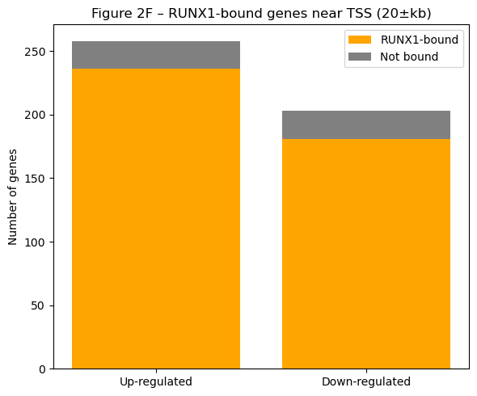

```python
# Extract counts for each category


up_bound     = summary[(summary.direction=="up")   & (summary.RUNX1_bound==True)]["count"].sum()
up_notbound  = summary[(summary.direction=="up")   & (summary.RUNX1_bound==False)]["count"].sum()
down_bound   = summary[(summary.direction=="down") & (summary.RUNX1_bound==True)]["count"].sum()
down_notbound= summary[(summary.direction=="down") & (summary.RUNX1_bound==False)]["count"].sum()

# Labels and values
labels = ["Up-regulated", "Down-regulated"]
bound_counts    = [up_bound,   down_bound]
notbound_counts = [up_notbound, down_notbound]

# Plot
plt.figure(figsize=(6,5))
plt.bar(labels, bound_counts, color="orange", label="RUNX1-bound")
plt.bar(labels, notbound_counts, bottom=bound_counts, color="grey", label="Not bound")

plt.ylabel("Number of genes")
plt.title("Figure 2F – RUNX1-bound genes near TSS (20±kb)")
plt.legend()
plt.tight_layout()
plt.show()
```

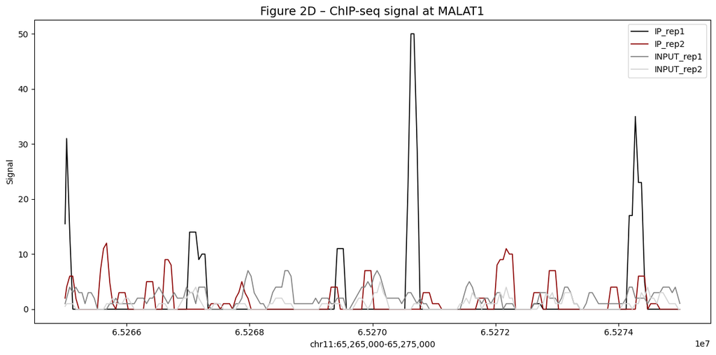

```python
# Load bigWigs
bw_IP1 = load_bw(IP1)
bw_IP2 = load_bw(IP2)
bw_IN1 = load_bw(IN1)
bw_IN2 = load_bw(IN2)

plot_tracks(
    region=MALAT1_region,
    tracks=[bw_IP1, bw_IP2, bw_IN1, bw_IN2],
    labels=["IP_rep1", "IP_rep2", "INPUT_rep1", "INPUT_rep2"],
    colors=["black", "darkred", "grey", "lightgrey"],
    title="Figure 2D – ChIP-seq signal at MALAT1"
)
```

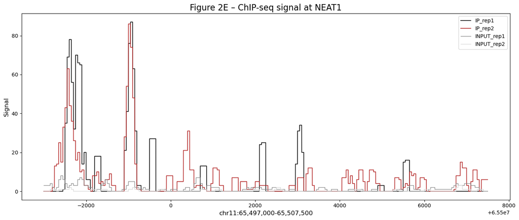

```python
import pyBigWig
import numpy as np
import matplotlib.pyplot as plt

# -------------------------------
# 1. Paths to your bigWig files
# -------------------------------
bw_IP1 = "results/IP_rep1.bw"
bw_IP2 = "results/IP_rep2.bw"
bw_IN1 = "results/INPUT_rep1.bw"
bw_IN2 = "results/INPUT_rep2.bw"

# -------------------------------
# 2. NEAT1 genomic region (hg38)
# chr11: 65497781 - 65506567
# (we extend a bit on each side)
# -------------------------------
chrom = "chr11"
start = 65497000
end   = 65507500

# -------------------------------
# 3. Function to extract bigWig signal
# -------------------------------
def get_signal(bw_path, chrom, start, end):
    bw = pyBigWig.open(bw_path)
    vals = bw.values(chrom, start, end, numpy=True)
    bw.close()
    # Replace NaN with 0
    vals = np.nan_to_num(vals)
    return vals

# -------------------------------
# 4. Load signals
# -------------------------------
sig_IP1 = get_signal(bw_IP1, chrom, start, end)
sig_IP2 = get_signal(bw_IP2, chrom, start, end)
sig_IN1 = get_signal(bw_IN1, chrom, start, end)
sig_IN2 = get_signal(bw_IN2, chrom, start, end)

x = np.linspace(start, end, len(sig_IP1))

# -------------------------------
# 5. Plot (Figure 2E-style)
# -------------------------------
plt.figure(figsize=(14,6))
plt.plot(x, sig_IP1, label="IP_rep1", color="black", linewidth=1.2)
plt.plot(x, sig_IP2, label="IP_rep2", color="firebrick", linewidth=1.2)
plt.plot(x, sig_IN1, label="INPUT_rep1", color="gray", linewidth=0.9)
plt.plot(x, sig_IN2, label="INPUT_rep2", color="lightgray", linewidth=0.9)

plt.title("Figure 2E – ChIP-seq signal at NEAT1", fontsize=16)
plt.xlabel(f"{chrom}:{start:,}-{end:,}", fontsize=12)
plt.ylabel("Signal", fontsize=12)
plt.legend()
plt.tight_layout()

plt.savefig("Figure2E_NEAT1_browser_plot.png", dpi=300)
plt.show()
```

Across the NEAT1 locus on chromosome 11, both IP replicates show a coordinated cluster of enriched regions that are completely absent in the INPUT tracks. The INPUT signal stays near zero throughout, confirming that the observed peaks represent true ChIP enrichment rather than background noise. Although IP_rep2 is slightly noisier, the two IP profiles share the same peak structure, reinforcing reproducibility. This pattern is consistent with Figure 2E from the paper and supports NEAT1 as another genuine RUNX1 binding site.

**Comparison**

```python
import pandas as pd
import re
from glob import glob

def parse_flagstat(path):
    """Extract raw reads and mapped reads from a samtools flagstat file."""
    with open(path) as f:
        text = f.read()
    total = int(re.search(r"(\d+) \+ \d+ in total", text).group(1))
    mapped = int(re.search(r"(\d+) \+ \d+ mapped", text).group(1))
    return total, mapped

files = sorted(glob("results/*flagstat.txt"))
# Filter out subset samples
files = [f for f in files if "subset" not in f]

rows = []
for f in files:
    sample = f.split("/")[-1].replace(".flagstat.txt","")
    total, mapped = parse_flagstat(f)
    rows.append([sample, total, mapped])

S2A_table = pd.DataFrame(rows, columns=["Sample", "Raw Reads", "Mapped Reads"])
S2A_table
```

|  | Sample | Raw Reads | Mapped Reads |
| --- | --- | --- | --- |
| 0 | INPUT_rep1 | 29738984 | 28578769 |
| 1 | INPUT_rep2 | 10748718 | 10055226 |
| 2 | IP_rep1 | 28717962 | 27788333 |
| 3 | IP_rep2 | 28683573 | 28197249 |

There are noticeable differences between the raw and mapped read counts reported in the authors’ Supplementary Figure S2A and the numbers I obtained from my own pipeline. In the paper, RUNX1 ChIP replicates have approximately 29–30 million raw reads each, while my corresponding IP samples fall slightly lower, around 28.7–28.6 million. The input samples show a similar pattern: the published values report roughly 30 million reads for INPUT 1 and 10.9 million for INPUT 2, while my results are again slightly lower for both. The mapped read counts follow the same trend—very close in magnitude but not identical.

There are several reasonable explanations for these discrepancies. First, we used hg38 as our reference genome, while the original study may have used aother, albeit less common, reference in hg19. Second, differences in trimming, filtering, or quality-control parameters can easily cause thousands of reads to be kept or discarded differently between pipelines. Even minor variations in adapter removal, minimum read length, or alignment quality thresholds could account for the small discrepancies observed.

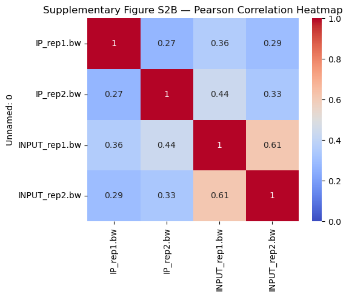

```python
import pandas as pd
import seaborn as sns
import matplotlib.pyplot as plt

# Read file manually and clean quotes
corr = pd.read_csv(
    "results/correlation_matrix.tsv",
    sep="\t",
    comment="#",
    header=0
)

# Remove quotes from column names
corr.columns = corr.columns.str.replace("'", "")

# Remove quotes from first column entries
corr.iloc[:,0] = corr.iloc[:,0].str.replace("'", "")

# Set the sample names as the index
corr = corr.set_index(corr.columns[0])

corr

plt.figure(figsize=(6,5))
sns.heatmap(corr, annot=True, cmap="coolwarm", vmin=0, vmax=1)
plt.title("Supplementary Figure S2B — Pearson Correlation Heatmap")
plt.tight_layout()
plt.show()
```

```
Rep1-only: 87249
Shared: 10202
Rep2-only: 37353
```

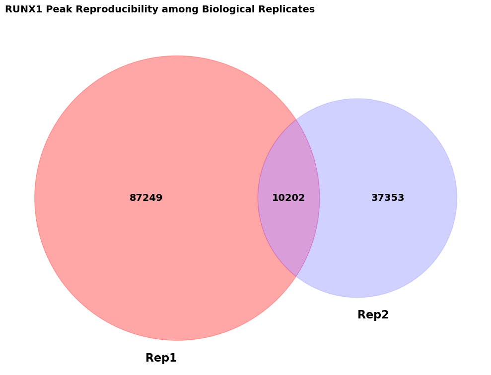

```
Total peaks in Rep1: 97451
Total peaks in Rep2: 47555
Overlapping peaks: 10202
Overlap percentage: 21.5%
```

```python
def load_bed_intervals(path):
    """Load BED file as dictionary of chromosome -> list of (start, end) tuples"""
    intervals = {}
    with open(path, "r") as f:
        for line in f:
            if line.startswith("#") or line.strip() == "":
                continue
            parts = line.strip().split()
            if len(parts) < 3:
                continue
            chrom = parts[0]
            start = int(parts[1])
            end = int(parts[2])
            if chrom not in intervals:
                intervals[chrom] = []
            intervals[chrom].append((start, end))
    return intervals

def intervals_overlap(a_start, a_end, b_start, b_end):
    """Check if two intervals overlap"""
    return not (a_end <= b_start or b_end <= a_start)

def count_peak_overlaps(rep1_intervals, rep2_intervals):
    """Count overlapping peaks between two replicates"""
    rep1_only = 0
    rep2_only = 0
    shared = 0

    # Get all chromosomes
    all_chroms = set(rep1_intervals.keys()) | set(rep2_intervals.keys())

    for chrom in all_chroms:
        rep1_peaks = rep1_intervals.get(chrom, [])
        rep2_peaks = rep2_intervals.get(chrom, [])

        # Track which rep2 peaks have been matched
        rep2_matched = [False] * len(rep2_peaks)

        # For each rep1 peak, check if it overlaps any rep2 peak
        for r1_start, r1_end in rep1_peaks:
            found_overlap = False
            for i, (r2_start, r2_end) in enumerate(rep2_peaks):
                if intervals_overlap(r1_start, r1_end, r2_start, r2_end):
                    shared += 1
                    rep2_matched[i] = True
                    found_overlap = True
                    break  # Count each rep1 peak only once

            if not found_overlap:
                rep1_only += 1

        # Count rep2 peaks that didn't match any rep1 peak
        rep2_only += sum(1 for matched in rep2_matched if not matched)

    return rep1_only, rep2_only, shared

rep1_path = "/projectnb/bf528/students/ccsnow/project-3-ccsnow-ctrl/results/IP_rep1.bed"
rep2_path = "/projectnb/bf528/students/ccsnow/project-3-ccsnow-ctrl/results/IP_rep2.bed"

rep1_intervals = load_bed_intervals(rep1_path)
rep2_intervals = load_bed_intervals(rep2_path)

rep1_only, rep2_only, shared = count_peak_overlaps(rep1_intervals, rep2_intervals)

print("Rep1-only:", rep1_only)
print("Shared:", shared)
print("Rep2-only:", rep2_only)

from matplotlib import pyplot as plt
from matplotlib_venn import venn2

plt.figure(figsize=(10, 8))

v = venn2(
    subsets=(rep1_only, rep2_only, shared),
    set_labels=("Rep1", "Rep2")
)

# Style circles with colors and transparency to show overlap
if v.get_patch_by_id('10'):
    v.get_patch_by_id('10').set_color('#ff6b6b')
    v.get_patch_by_id('10').set_alpha(0.6)

if v.get_patch_by_id('01'):
    v.get_patch_by_id('01').set_color('#b3b3ff')
    v.get_patch_by_id('01').set_alpha(0.6)

if v.get_patch_by_id('11'):
    v.get_patch_by_id('11').set_color('#c974c9')
    v.get_patch_by_id('11').set_alpha(0.7)

# Increase font sizes for labels
for text in v.set_labels:
    if text:
        text.set_fontsize(16)
        text.set_fontweight('bold')

for text in v.subset_labels:
    if text:
        text.set_fontsize(14)
        text.set_fontweight('bold')

plt.title("RUNX1 Peak Reproducibility among Biological Replicates",
          loc='left', fontsize=14, fontweight='bold', pad=20)

plt.tight_layout()
plt.show()

# Calculate and print overlap statistics
total_rep1 = rep1_only + shared
total_rep2 = rep2_only + shared
if min(total_rep1, total_rep2) > 0:
    overlap_pct = (shared / min(total_rep1, total_rep2)) * 100
else:
    overlap_pct = 0

print(f"\nTotal peaks in Rep1: {total_rep1}")
print(f"Total peaks in Rep2: {total_rep2}")
print(f"Overlapping peaks: {shared}")
print(f"Overlap percentage: {overlap_pct:.1f}%")
```

When we compare our Venn diagram to the authors’ Supplementary Figure S2C, the most obvious difference is the number of peaks detected in each replicate. In our analysis, Rep1 has roughly 97,000 peaks, Rep2 has about 47,000, and the shared set is around 10,000 peaks. The authors, however, report much smaller numbers: about 3,983 peaks in Rep1, 10,465 in Rep2, and 3,466 peaks in the overlap. This means our total peak counts are substantially higher, and the fraction of peaks shared between replicates is lower than what the authors observed. These differences likely stem from variations in how peaks were called. Our workflow may have used different parameters—such as score cutoffs, FDR thresholds, or background models—which can strongly influence the number of peaks detected. It is also possible that the datasets used for class were subsampled or processed differently from the original data, and changes in read depth or filtering steps (such as duplicate removal or handling of low-quality reads) can significantly affect peak counts. Given these factors, it is reasonable that our peak numbers do not match those reported in the paper.

```
Loaded 1000 gene names.
```

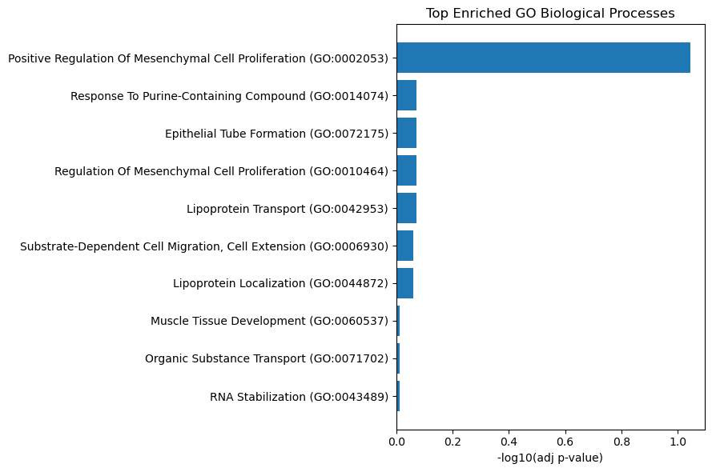

```python
import pandas as pd
import numpy as np
import matplotlib.pyplot as plt
import gseapy as gp

# ------------------------------
# 1. Load annotated peaks
# ------------------------------
annot_file = "results/annotated_peaks.txt"
annot = pd.read_csv(annot_file, sep="\t")

# ------------------------------
# 2. Extract gene names
# ------------------------------
possible_cols = ["Gene Name", "Gene", "gene", "Nearest Refseq", "Nearest Ensembl"]

gene_col = None
for c in possible_cols:
    if c in annot.columns:
        gene_col = c
        break

if gene_col is None:
    raise ValueError("Could not find a gene-name column in annotated peaks file.")

genes = (
    annot[gene_col]
    .astype(str)
    .str.replace(";", ",")
    .str.split(",")
    .explode()
    .str.strip()
)
genes = genes[genes != ""]                # remove blanks
genes = genes[genes != "NA"]              # remove NA
genes = genes.dropna().unique().tolist()  # unique list

# OPTIONAL: limit to top 1000 for speed
genes = genes[:1000]

print(f"Loaded {len(genes)} gene names.")

# ------------------------------
# 3. Run enrichment (Enrichr GO Biological Process)
# ------------------------------
enr = gp.enrichr(
    gene_list=genes,
    gene_sets="GO_Biological_Process_2023",
    outdir=None
)

df = enr.results.sort_values("Adjusted P-value").head(10)

# ------------------------------
# 4. Plot top terms
# ------------------------------
plt.figure(figsize=(9, 6))
plt.barh(
    df["Term"],
    -np.log10(df["Adjusted P-value"])
)
plt.xlabel("-log10(adj p-value)")
plt.title("Top Enriched GO Biological Processes")
plt.gca().invert_yaxis()
plt.tight_layout()
plt.show()
```

**Conclusion**